# 1822 Administrative Analyst Performance Task

Jie Heng Yu

10/28/2023

# Datasets

```r
surveyResponses <- as_tibble(read.csv('survey_responses.csv'))
testScores <- as_tibble(read.csv('test_scores.csv'))
testScores
```

```
## # A tibble: 21,059 × 18
##    Schno School   Calgrade Englang Econ_Dis Sped  HL    NA.   Asian Hawaiian
##    <int> <chr>       <int> <chr>   <chr>    <chr> <chr> <chr> <chr> <chr>
##  1   413 Alamo ES        3 EO      Yes      No    No    No    Yes   No
##  2   413 Alamo ES        3 EO      No       No    No    No    No    No
##  3   413 Alamo ES        3 EO      No       No    No    No    Yes   No
##  4   413 Alamo ES        3 EL      Yes      No    Yes   No    No    No
##  5   413 Alamo ES        3 EO      No       No    No    No    No    No
##  6   413 Alamo ES        3 EL      Yes      No    No    No    Yes   No
##  7   413 Alamo ES        3 EL      No       No    No    No    Yes   No
##  8   413 Alamo ES        3 EO      Yes      Yes   No    No    Yes   No
##  9   413 Alamo ES        3 EL      Yes      No    Yes   No    No    No
## 10   413 Alamo ES        3 IFEP    No       No    No    No    Yes   No
## # ℹ 21,049 more rows
## # ℹ 8 more variables: Filipino <chr>, AA <chr>, White <chr>, Multi_Race <chr>,
## #   ELASS <int>, ELA_AL <int>, MathSS <int>, Math_AL <int>
```

```r
surveyResponses
```

```
## # A tibble: 4,984 × 8
##    schno school   span       group           domain construct favorability count
##    <int> <chr>    <chr>      <chr>           <chr>  <chr>            <int> <int>
##  1     0 District Elementary African Americ… Cultu… Climate …           78    NA
##  2     0 District Elementary African Americ… Cultu… Knowledg…           66    NA
##  3     0 District Elementary African Americ… Cultu… Safety              55    NA
##  4     0 District Elementary African Americ… Cultu… Sense of…           65    NA
##  5     0 District Elementary African Americ… Socia… Growth M…           59    NA
##  6     0 District Elementary African Americ… Socia… Self-Eff…           60    NA
##  7     0 District Elementary African Americ… Socia… Self-Man…           57    NA
##  8     0 District Elementary African Americ… Socia… Social A…           62    NA
##  9     0 District Elementary All             Cultu… Climate …           80    NA
## 10     0 District Elementary All             Cultu… Knowledg…           75    NA
## # ℹ 4,974 more rows
```

# Data Preparation

```r
testScoresDF <- filter(testScores, grepl('K-8', School))
surveyResponsesDF <- filter(surveyResponses, grepl('K8', school))
testScoresDF$School <- recode(testScoresDF$School, 'Buena Vista Horace Mann K-8' = 'Buena Vista / Mann K8', 'Lawton K-8' = 'Lawton Alt K8', 'Lilienthal (Claire) K-8' = 'Lilienthal Alt K8', 'Rooftop K-8' = 'Rooftop Alt K8', 'Yu (Alice Fong) K-8' = 'Yu (A.F.) Alt K8')
testScoresDF <- filter(testScoresDF, School %in% c('Buena Vista / Mann K8', 'Lawton Alt K8', 'Lilienthal Alt K8', 'Rooftop Alt K8', 'Yu (A.F.) Alt K8'))
testScoresDF$Asian[testScoresDF$Hawaiian == 'Yes'] <- 'Yes'
testScoresDF <- select(testScoresDF, -NA., -Filipino, -Multi_Race, -Hawaiian)
surveyResponsesDF <- select(surveyResponsesDF, -count) %>%
  filter(group %in% c('African American', 'Hispanic/Latino', 'Asian', 'White', 'ELL', 'SPED', 'Low SES'))
testScoresDF$Calgrade <- case_when(testScoresDF$Calgrade %in% 1:5 ~ 'Elementary',
                                   TRUE ~ 'Middle')
testScoresDF
```

```
## # A tibble: 1,670 × 14
##    Schno School    Calgrade Englang Econ_Dis Sped  HL    Asian AA    White ELASS
##    <int> <chr>     <chr>    <chr>   <chr>    <chr> <chr> <chr> <chr> <chr> <int>
##  1   618 Buena Vi… Element… EL      Yes      No    Yes   No    No    No     2249
##  2   618 Buena Vi… Element… EO      Yes      No    Yes   No    No    No     2373
##  3   618 Buena Vi… Element… EL      Yes      Yes   Yes   No    No    No     2255
##  4   618 Buena Vi… Element… EO      No       Yes   Yes   No    No    No     2275
##  5   618 Buena Vi… Element… EO      No       No    No    No    No    Yes    2401
##  6   618 Buena Vi… Element… EL      Yes      No    Yes   No    No    No     2393
##  7   618 Buena Vi… Element… EL      Yes      No    Yes   No    No    No     2425
##  8   618 Buena Vi… Element… EL      Yes      No    Yes   No    No    No     2341
##  9   618 Buena Vi… Element… EO      Yes      Yes   No    No    No    Yes    2404
## 10   618 Buena Vi… Element… EL      Yes      No    Yes   No    No    No     2227
## # ℹ 1,660 more rows
## # ℹ 3 more variables: ELA_AL <int>, MathSS <int>, Math_AL <int>
```

```r
surveyResponsesDF
```

```
## # A tibble: 272 × 7
##    schno school            span       group        domain construct favorability
##    <int> <chr>             <chr>      <chr>        <chr>  <chr>            <int>
##  1   479 Lilienthal Alt K8 Elementary Asian        Cultu… Climate …           84
##  2   479 Lilienthal Alt K8 Elementary Asian        Cultu… Knowledg…           84
##  3   479 Lilienthal Alt K8 Elementary Asian        Cultu… Safety              72
##  4   479 Lilienthal Alt K8 Elementary Asian        Cultu… Sense of…           83
##  5   479 Lilienthal Alt K8 Elementary Asian        Socia… Growth M…           64
##  6   479 Lilienthal Alt K8 Elementary Asian        Socia… Self-Eff…           58
##  7   479 Lilienthal Alt K8 Elementary Asian        Socia… Self-Man…           80
##  8   479 Lilienthal Alt K8 Elementary Asian        Socia… Social A…           68
##  9   479 Lilienthal Alt K8 Elementary Hispanic/La… Cultu… Climate …           79
## 10   479 Lilienthal Alt K8 Elementary Hispanic/La… Cultu… Knowledg…           81
## # ℹ 262 more rows
```

# Student Performance based on Growth Mindset

We can get an idea of students’ growth mindsets based on their favorability of the constructs of Social-Emotional Learning. I am also going to assume that the school that a student goes to has a major affect on his/her growth mindset, so I will be looking at favorability for each K-8 school.

```r
filter(surveyResponsesDF, domain == 'Social-Emotional Learning') %>%
  group_by(school, construct) %>%
  summarise(avg_favor = mean(favorability))
```

```
## # A tibble: 20 × 3
## # Groups:   school [5]
##    school               construct        avg_favor
##    <chr>                <chr>                <dbl>
##  1 Buena Vista/ Mann K8 Growth Mindset        46.9
##  2 Buena Vista/ Mann K8 Self-Efficacy         41.5
##  3 Buena Vista/ Mann K8 Self-Management       60.9
##  4 Buena Vista/ Mann K8 Social Awareness      54.2
##  5 Lawton Alt K8        Growth Mindset        63.8
##  6 Lawton Alt K8        Self-Efficacy         53.5
##  7 Lawton Alt K8        Self-Management       80.5
##  8 Lawton Alt K8        Social Awareness      62.2
##  9 Lilienthal Alt K8    Growth Mindset        69
## 10 Lilienthal Alt K8    Self-Efficacy         58.7
## 11 Lilienthal Alt K8    Self-Management       77.9
## 12 Lilienthal Alt K8    Social Awareness      65.2
## 13 Rooftop Alt K8       Growth Mindset        65.7
## 14 Rooftop Alt K8       Self-Efficacy         59.2
## 15 Rooftop Alt K8       Self-Management       76.3
## 16 Rooftop Alt K8       Social Awareness      65.3
## 17 Yu (A.F.) Alt K8     Growth Mindset        60.2
## 18 Yu (A.F.) Alt K8     Self-Efficacy         54.5
## 19 Yu (A.F.) Alt K8     Self-Management       75.5
## 20 Yu (A.F.) Alt K8     Social Awareness      62
```

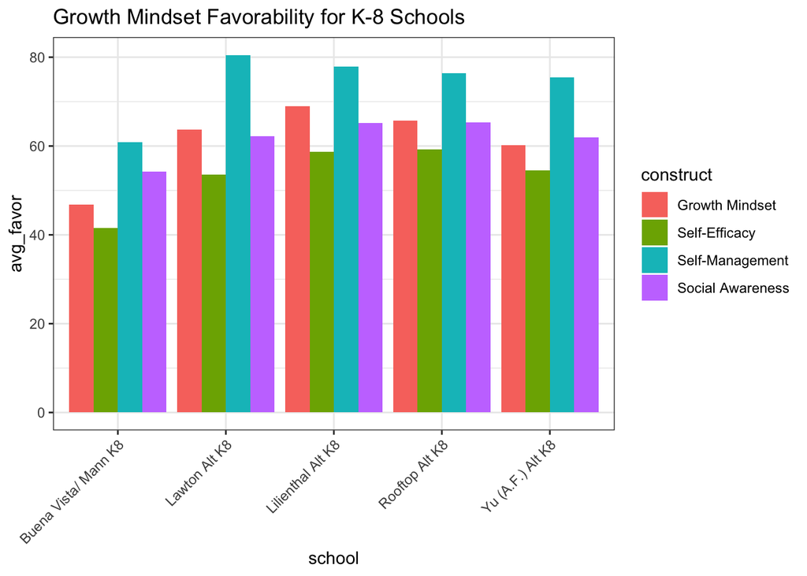

```r
ggplot(filter(surveyResponsesDF, domain == 'Social-Emotional Learning') %>%
         group_by(school, construct) %>%
         summarise(avg_favor = mean(favorability)),
       aes(x = school, y = avg_favor, fill = construct)) +
  geom_bar(position = 'dodge', stat = 'identity') +
  labs(title = 'Growth Mindset Favorability for K-8 Schools') +
  theme_bw() +
  theme(axis.text.x = element_text(angle = 45, vjust = 1, hjust = 1))
```

Now, let’s see the average scaled score for the English & Math assessments for each school.

```r
testScoresDF %>%
  group_by(School) %>%
  summarise(avg_ELASS = mean(ELASS),
            avg_MathSS = mean(MathSS)) %>%
  pivot_longer(cols = c('avg_ELASS', 'avg_MathSS'),
               names_to = 'measure', values_to = 'scores')
```

```
## # A tibble: 10 × 3
##    School                measure    scores
##    <chr>                 <chr>       <dbl>
##  1 Buena Vista / Mann K8 avg_ELASS   2445.
##  2 Buena Vista / Mann K8 avg_MathSS  2460.
##  3 Lawton Alt K8         avg_ELASS   2585.
##  4 Lawton Alt K8         avg_MathSS  2601.
##  5 Lilienthal Alt K8     avg_ELASS   2572.
##  6 Lilienthal Alt K8     avg_MathSS  2574.
##  7 Rooftop Alt K8        avg_ELASS   2522.
##  8 Rooftop Alt K8        avg_MathSS  2527.
##  9 Yu (A.F.) Alt K8      avg_ELASS   2581.
## 10 Yu (A.F.) Alt K8      avg_MathSS  2592.
```

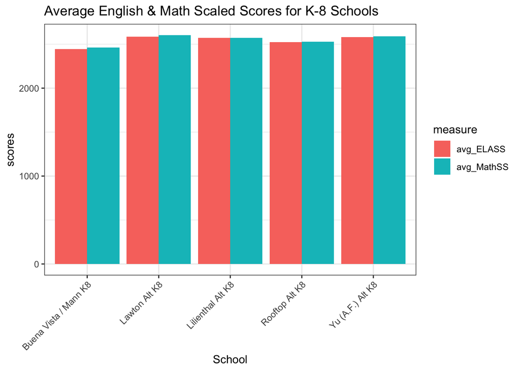

```r
ggplot(testScoresDF %>%
         group_by(School) %>%
         summarise(avg_ELASS = mean(ELASS),
                   avg_MathSS = mean(MathSS)) %>%
         pivot_longer(cols = c('avg_ELASS', 'avg_MathSS'),
                      names_to = 'measure', values_to = 'scores'),
       aes(x = School, y = scores, fill = measure)) +
  geom_bar(position = 'dodge', stat = 'identity') +
  labs(title = 'Average English & Math Scaled Scores for K-8 Schools') +
  theme_bw() +
  theme(axis.text.x = element_text(angle = 45, vjust = 1, hjust = 1))
```

Based on the above two figures, there may be a relationship that if students’ favorability their growth mindsets is lower, that they we will perform worse on the English & Math assessment.

We’ll consolidate the students’ favorability of their growth mindset for each school & the assessment scores for each school, & then create a model for their relationship.

```r
x <- filter(surveyResponsesDF, domain == 'Social-Emotional Learning') %>%
  group_by(school) %>%
  summarise(avg_favor = mean(favorability))
x
```

```
## # A tibble: 5 × 2
##   school               avg_favor
##   <chr>                    <dbl>
## 1 Buena Vista/ Mann K8      50.9
## 2 Lawton Alt K8             65
## 3 Lilienthal Alt K8         67.7
## 4 Rooftop Alt K8            66.6
## 5 Yu (A.F.) Alt K8          63.1
```

```r
y <- testScoresDF %>%
  group_by(School) %>%
  summarise(avg_ELASS = mean(ELASS),
            avg_MathSS = mean(MathSS),
            avg_Math_ELA = (avg_ELASS + avg_MathSS)/2)
y
```

```
## # A tibble: 5 × 4
##   School                avg_ELASS avg_MathSS avg_Math_ELA
##   <chr>                     <dbl>      <dbl>        <dbl>
## 1 Buena Vista / Mann K8     2445.      2460.        2453.
## 2 Lawton Alt K8             2585.      2601.        2593.
## 3 Lilienthal Alt K8         2572.      2574.        2573.
## 4 Rooftop Alt K8            2522.      2527.        2525.
## 5 Yu (A.F.) Alt K8          2581.      2592.        2586.
```

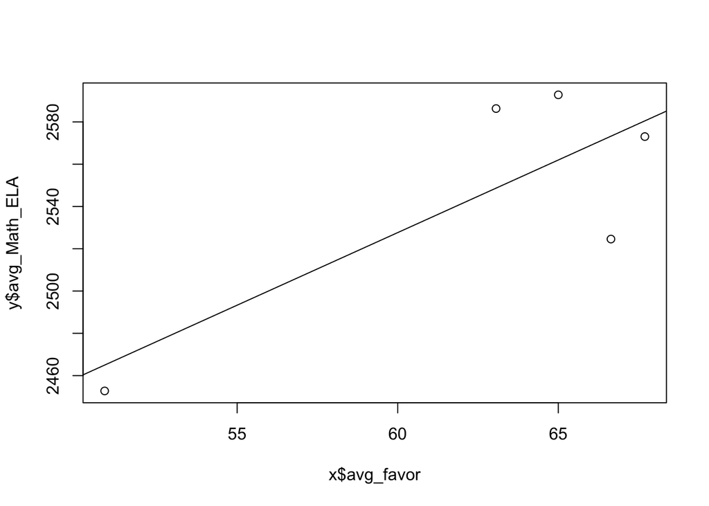

```r
plot(x$avg_favor, y$avg_Math_ELA)
abline(lm(y$avg_Math_ELA ~ x$avg_favor))
```

```r
summary(lm(y$avg_Math_ELA ~ x$avg_favor))
```

```
##
## Call:
## lm(formula = y$avg_Math_ELA ~ x$avg_favor)
##
## Residuals:
##      1      2      3      4      5
## -12.23  30.79  -7.47 -48.70  37.61
##
## Coefficients:
##             Estimate Std. Error t value Pr(>|t|)
## (Intercept) 2115.456    187.447  11.286  0.00149 **
## x$avg_favor    6.870      2.978   2.307  0.10429
## ---
## Signif. codes:  0 '***' 0.001 '**' 0.01 '*' 0.05 '.' 0.1 ' ' 1
##
## Residual standard error: 40.58 on 3 degrees of freedom
## Multiple R-squared:  0.6396, Adjusted R-squared:  0.5194
## F-statistic: 5.323 on 1 and 3 DF,  p-value: 0.1043
```

# Student Performance based on Growth Mindset, Faceted Across SubGroups

Since race is independent in this dataset & SES/SPED/ELL are non-independent, we’ll analyse them separately. We will calculate assessment scores for SES/SPED/ELL individually though, for accuracy. Starting with race.

```r
filter(surveyResponsesDF, domain == 'Social-Emotional Learning' & group %in% c('African American', 'Hispanic/Latino', 'Asian', 'White')) %>%
  group_by(school, group, construct) %>%
  summarise(avg_favor = mean(favorability))
```

```
## # A tibble: 36 × 4
## # Groups:   school, group [9]
##    school               group           construct        avg_favor
##    <chr>                <chr>           <chr>                <dbl>
##  1 Buena Vista/ Mann K8 Hispanic/Latino Growth Mindset        50.5
##  2 Buena Vista/ Mann K8 Hispanic/Latino Self-Efficacy         45.5
##  3 Buena Vista/ Mann K8 Hispanic/Latino Self-Management       65
##  4 Buena Vista/ Mann K8 Hispanic/Latino Social Awareness      58
##  5 Lawton Alt K8        Asian           Growth Mindset        64.5
##  6 Lawton Alt K8        Asian           Self-Efficacy         54
##  7 Lawton Alt K8        Asian           Self-Management       80.5
##  8 Lawton Alt K8        Asian           Social Awareness      62
##  9 Lilienthal Alt K8    Asian           Growth Mindset        73
## 10 Lilienthal Alt K8    Asian           Self-Efficacy         62.5
## # ℹ 26 more rows
```

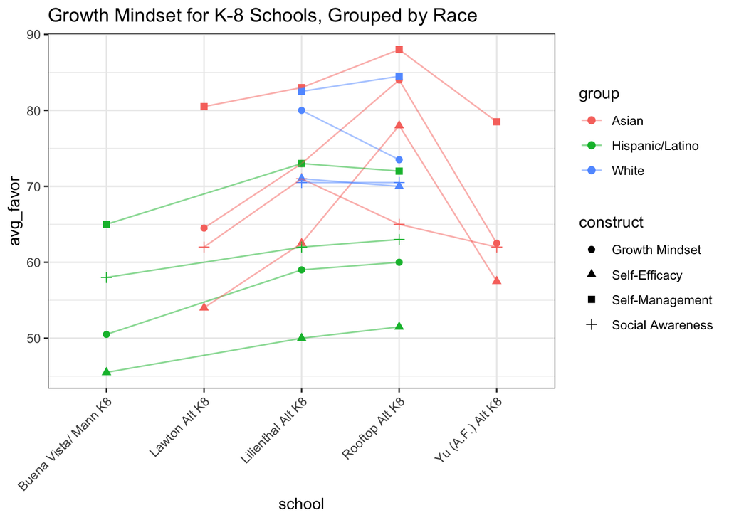

```r
ggplot(filter(surveyResponsesDF, domain == 'Social-Emotional Learning' & group %in% c('African American', 'Hispanic/Latino', 'Asian', 'White')) %>%
         group_by(school, group, construct) %>%
         summarise(avg_favor = mean(favorability)),
       aes(x = school, y = avg_favor, colour = group, shape = construct,
           group = interaction(group, construct))) +
  geom_point(size = 2) + geom_line(alpha = 0.5) +
  labs(title = 'Growth Mindset for K-8 Schools, Grouped by Race') +
  theme_bw() +
  theme(axis.text.x = element_text(angle = 45, vjust = 1, hjust = 1))
```

Surprisingly (at least to me), African Americans do not attend these K-8 schools. Hispanics/Latinos seem to have lower favor of their own growth mindset when compared to Whites & Asians at these K-8 schools that have Hispanic/Latino, White, & Asian students. We’ll look at English & Math assessment scores for existing races in each school. Based on the figure above, Buena Vista only has Hispanic/Latinos, Lawton only has Asians, Lilienthal has Hispanic/Latinos, Asians & Whites, so does Rooftop, A.F. Yu only has Asians.

```r
a <- testScoresDF %>%
  group_by(School, AA, HL, Asian, White) %>%
  summarise(avg_ELASS = mean(ELASS),
            avg_MathSS = mean(MathSS)) %>%
  filter(AA == 'Yes' | HL == 'Yes' | Asian == 'Yes' | White == 'Yes')
```

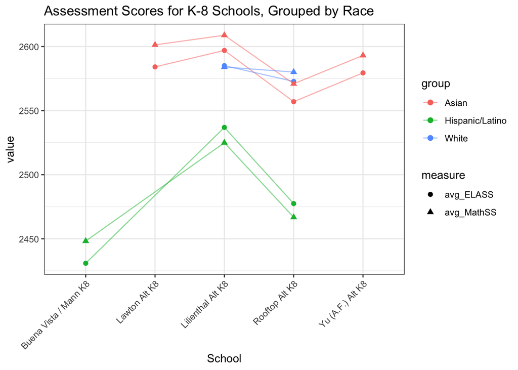

```r
a$group <- apply(a, 1, function(x) {
  case_when(x['AA'] == 'Yes' ~ 'African American',
            x['HL'] == 'Yes' ~ 'Hispanic/Latino',
            x['Asian'] == 'Yes' ~ 'Asian',
            x['White'] == 'Yes' ~ 'White')
})
a <- as_tibble(a) %>% select(School, group, avg_ELASS, avg_MathSS) %>%
  filter((School == 'Buena Vista / Mann K8' & group == 'Hispanic/Latino') | (School == 'Lawton Alt K8' & group == 'Asian') | (School == 'Lilienthal Alt K8' & group != 'African American') | (School == 'Rooftop Alt K8' & group != 'African American') | (School == 'Yu (A.F.) Alt K8' & group == 'Asian')) %>%
  pivot_longer(cols = c('avg_ELASS', 'avg_MathSS'),
               names_to = 'measure', values_to = 'value')
ggplot(a, aes(x = School, y = value, colour = group, shape = measure,
              group = interaction(group, measure))) +
  geom_point(size = 2) + geom_line(alpha = 0.5) +
  labs(title = 'Assessment Scores for K-8 Schools, Grouped by Race') +
  theme_bw() +
  theme(axis.text.x = element_text(angle = 45, vjust = 1, hjust = 1))
```

The shape of the visualisations of assessment scores for k-8 schools grouped by race seems to mimic the shape of the visualisations of growth mindset favorability for k-8 schools grouped by race, so maybe there is a relationship between the two?

```r
b <- filter(surveyResponsesDF, domain == 'Social-Emotional Learning' & group %in% c('African American', 'Hispanic/Latino', 'Asian', 'White')) %>%
  group_by(school, group) %>%
  summarise(avg_favor = mean(favorability)) %>%
  as_tibble()
b
```

```
## # A tibble: 9 × 3
##   school               group           avg_favor
##   <chr>                <chr>               <dbl>
## 1 Buena Vista/ Mann K8 Hispanic/Latino      54.8
## 2 Lawton Alt K8        Asian                65.2
## 3 Lilienthal Alt K8    Asian                72.4
## 4 Lilienthal Alt K8    Hispanic/Latino      61
## 5 Lilienthal Alt K8    White                76
## 6 Rooftop Alt K8       Asian                78.8
## 7 Rooftop Alt K8       Hispanic/Latino      61.6
## 8 Rooftop Alt K8       White                74.6
## 9 Yu (A.F.) Alt K8     Asian                65.1
```

```r
c <- a %>% group_by(School, group) %>%
  summarise(avg_Math_ELA = mean(value)) %>% as_tibble()
c
```

```
## # A tibble: 9 × 3
##   School                group           avg_Math_ELA
##   <chr>                 <chr>                  <dbl>
## 1 Buena Vista / Mann K8 Hispanic/Latino        2440.
## 2 Lawton Alt K8         Asian                  2593.
## 3 Lilienthal Alt K8     Asian                  2603.
## 4 Lilienthal Alt K8     Hispanic/Latino        2531.
## 5 Lilienthal Alt K8     White                  2585.
## 6 Rooftop Alt K8        Asian                  2564.
## 7 Rooftop Alt K8        Hispanic/Latino        2472.
## 8 Rooftop Alt K8        White                  2576.
## 9 Yu (A.F.) Alt K8      Asian                  2586.
```

Combine both into one data set, recode group variables into numeric so multiple model can understand. For Schools, 1 = Buena Vista, 2 = Lawton, 3 = Lilienthal, 4 = Rooftop, 5 = A.F. Yu. For groups, 1 = Hispanic/Latino, 2 = Asian, 3 = White.

```r
c <- mutate(c, avg_favor = b$avg_favor)
c$School <- recode(c$School, 'Buena Vista / Mann K8' = 1, 'Lawton Alt K8' = 2,
                   'Lilienthal Alt K8' = 3, 'Rooftop Alt K8' = 4,
                   'Yu (A.F.) Alt K8' = 5)
c$group <- recode(c$group, 'Hispanic/Latino' = 1, 'Asian' = 2, 'White' = 3)
c
```

```
## # A tibble: 9 × 4
##   School group avg_Math_ELA avg_favor
##    <dbl> <dbl>        <dbl>     <dbl>
## 1      1     1        2440.      54.8
## 2      2     2        2593.      65.2
## 3      3     2        2603.      72.4
## 4      3     1        2531.      61
## 5      3     3        2585.      76
## 6      4     2        2564.      78.8
## 7      4     1        2472.      61.6
## 8      4     3        2576.      74.6
## 9      5     2        2586.      65.1
```

```r
summary(lm(c$avg_Math_ELA ~ c$avg_favor + c$School + c$group))
```

```
##
## Call:
## lm(formula = c$avg_Math_ELA ~ c$avg_favor + c$School + c$group)
##
## Residuals:
##      1      2      3      4      5      6      7      8      9
## -40.36  50.58  40.78  27.31 -20.26 -16.63 -38.28 -31.07  27.92
##
## Coefficients:
##             Estimate Std. Error t value Pr(>|t|)
## (Intercept) 2327.684    185.892  12.522 5.76e-05 ***
## c$avg_favor    2.035      3.692   0.551    0.605
## c$School       5.494     15.234   0.361    0.733
## c$group       35.325     35.675   0.990    0.368
## ---
## Signif. codes:  0 '***' 0.001 '**' 0.01 '*' 0.05 '.' 0.1 ' ' 1
##
## Residual standard error: 45.81 on 5 degrees of freedom
## Multiple R-squared:  0.6062, Adjusted R-squared:   0.37
## F-statistic: 2.566 on 3 and 5 DF,  p-value: 0.1678
```

```
## `geom_line()`: Each group consists of only one observation.
## ℹ Do you need to adjust the group aesthetic?
```

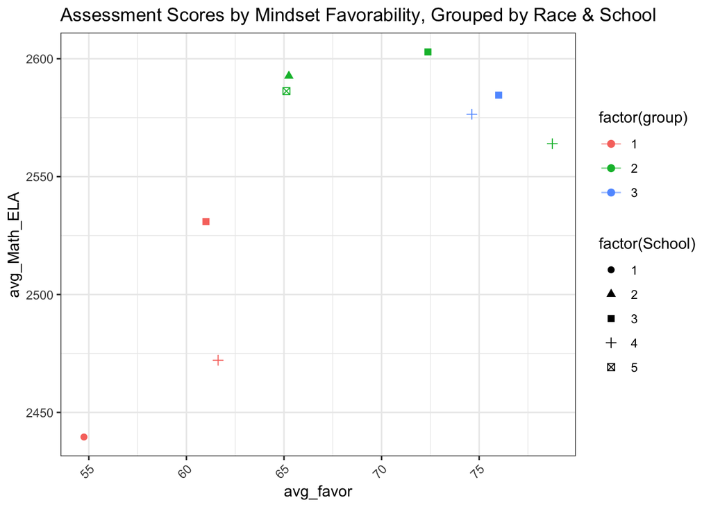

```r
ggplot(c, aes(x = avg_favor, y = avg_Math_ELA,
              colour = factor(group), shape = factor(School))) +
  geom_point(size = 2) + geom_line(alpha = 0.5) +
  labs(title = 'Assessment Scores by Mindset Favorability, Grouped by Race & School') +
  theme_bw() +
  theme(axis.text.x = element_text(angle = 45, vjust = 1, hjust = 1))
```

There is an positive relationship between favorability of growth mindset constructs & assessment scores. Hispanic/Latino students seem to perform the worse on the assessment compared Asians & White students at schools that house all three races & in general. Asian & White students seem to perform similarly on the assessment, receiving similar scores on average.

Now for dispositions.

```r
filter(surveyResponsesDF, domain == 'Social-Emotional Learning' & group %in% c('Low SES', 'SPED', 'ELL')) %>%
  group_by(school, group, construct) %>%
  summarise(avg_favor = mean(favorability))
```

```
## # A tibble: 36 × 4
## # Groups:   school, group [9]
##    school               group   construct        avg_favor
##    <chr>                <chr>   <chr>                <dbl>
##  1 Buena Vista/ Mann K8 ELL     Growth Mindset        42.5
##  2 Buena Vista/ Mann K8 ELL     Self-Efficacy         40.5
##  3 Buena Vista/ Mann K8 ELL     Self-Management       59.5
##  4 Buena Vista/ Mann K8 ELL     Social Awareness      53.5
##  5 Buena Vista/ Mann K8 Low SES Growth Mindset        47.5
##  6 Buena Vista/ Mann K8 Low SES Self-Efficacy         46
##  7 Buena Vista/ Mann K8 Low SES Self-Management       65
##  8 Buena Vista/ Mann K8 Low SES Social Awareness      58.5
##  9 Buena Vista/ Mann K8 SPED    Growth Mindset        47
## 10 Buena Vista/ Mann K8 SPED    Self-Efficacy         34
## # ℹ 26 more rows
```

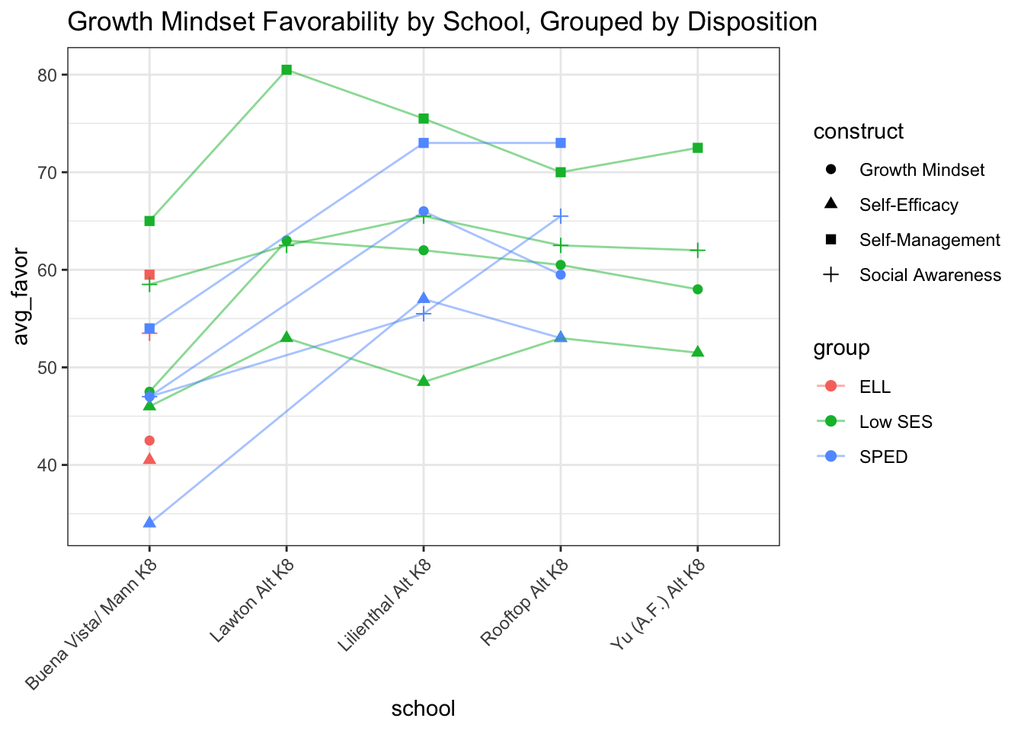

```r
ggplot(filter(surveyResponsesDF, domain == 'Social-Emotional Learning' & group %in% c('Low SES', 'SPED', 'ELL')) %>%
  group_by(school, group, construct) %>%
  summarise(avg_favor = mean(favorability)),
  aes(x = school, y = avg_favor, colour = group, shape = construct,
      group = interaction(group, construct))) +
  geom_point(size = 2) + geom_line(alpha = 0.5) +
  labs(title = 'Growth Mindset Favorability by School, Grouped by Disposition') +
  theme_bw() +
  theme(axis.text.x = element_text(angle = 45, vjust = 1, hjust = 1))
```

```r
filter(testScoresDF, Englang == 'EL') %>%
  group_by(School) %>%
  summarise(avg_ELASS = mean(ELASS),
            avg_MathSS = mean(MathSS),
            avg_Math_ELA = (avg_ELASS + avg_MathSS)/2)
```

```
## # A tibble: 5 × 4
##   School                avg_ELASS avg_MathSS avg_Math_ELA
##   <chr>                     <dbl>      <dbl>        <dbl>
## 1 Buena Vista / Mann K8     2382.      2403.        2393.
## 2 Lawton Alt K8             2482.      2513.        2497.
## 3 Lilienthal Alt K8         2469.      2474.        2471.
## 4 Rooftop Alt K8            2427.      2426.        2427.
## 5 Yu (A.F.) Alt K8          2456.      2499.        2478.
```

For SPED students:

```r
filter(testScoresDF, Sped == 'Yes') %>%
  group_by(School) %>%
  summarise(avg_ELASS = mean(ELASS),
            avg_MathSS = mean(MathSS),
            avg_Math_ELA = (avg_ELASS + avg_MathSS)/2)
```

```
## # A tibble: 4 × 4
##   School                avg_ELASS avg_MathSS avg_Math_ELA
##   <chr>                     <dbl>      <dbl>        <dbl>
## 1 Buena Vista / Mann K8     2382.      2398.        2390.
## 2 Lawton Alt K8             2458.      2479.        2468.
## 3 Lilienthal Alt K8         2539.      2546.        2543.
## 4 Rooftop Alt K8            2444.      2447.        2446.
```

For Low SES students:

```r
filter(testScoresDF, Econ_Dis == 'Yes') %>%
  group_by(School) %>%
  summarise(avg_ELASS = mean(ELASS),
            avg_MathSS = mean(MathSS),
            avg_Math_ELA = (avg_ELASS + avg_MathSS)/2)
```

```
## # A tibble: 5 × 4
##   School                avg_ELASS avg_MathSS avg_Math_ELA
##   <chr>                     <dbl>      <dbl>        <dbl>
## 1 Buena Vista / Mann K8     2416.      2435.        2426.
## 2 Lawton Alt K8             2576.      2590.        2583.
## 3 Lilienthal Alt K8         2530.      2527.        2528.
## 4 Rooftop Alt K8            2458.      2464.        2461.
## 5 Yu (A.F.) Alt K8          2582.      2598.        2590.
```

# Student Performance based on School Culture/Climate

```r
filter(surveyResponsesDF, domain == 'Culture/Climate') %>%
       group_by(school, construct) %>%
       summarise(avg_favor = mean(favorability))
```

```
## # A tibble: 20 × 3
## # Groups:   school [5]
##    school               construct                                      avg_favor
##    <chr>                <chr>                                              <dbl>
##  1 Buena Vista/ Mann K8 Climate of Support for Academic Learning            70.1
##  2 Buena Vista/ Mann K8 Knowledge and Fairness of Discipline, Rules a…      64.4
##  3 Buena Vista/ Mann K8 Safety                                              54.2
##  4 Buena Vista/ Mann K8 Sense of Belonging (School Connectedness)           64.5
##  5 Lawton Alt K8        Climate of Support for Academic Learning            81.2
##  6 Lawton Alt K8        Knowledge and Fairness of Discipline, Rules a…      72
##  7 Lawton Alt K8        Safety                                              66
##  8 Lawton Alt K8        Sense of Belonging (School Connectedness)           75.8
##  9 Lilienthal Alt K8    Climate of Support for Academic Learning            78.7
## 10 Lilienthal Alt K8    Knowledge and Fairness of Discipline, Rules a…      73.1
## 11 Lilienthal Alt K8    Safety                                              65.3
## 12 Lilienthal Alt K8    Sense of Belonging (School Connectedness)           71.7
## 13 Rooftop Alt K8       Climate of Support for Academic Learning            79.2
## 14 Rooftop Alt K8       Knowledge and Fairness of Discipline, Rules a…      66.3
## 15 Rooftop Alt K8       Safety                                              56.4
## 16 Rooftop Alt K8       Sense of Belonging (School Connectedness)           70.7
## 17 Yu (A.F.) Alt K8     Climate of Support for Academic Learning            77.5
## 18 Yu (A.F.) Alt K8     Knowledge and Fairness of Discipline, Rules a…      67.8
## 19 Yu (A.F.) Alt K8     Safety                                              56.8
## 20 Yu (A.F.) Alt K8     Sense of Belonging (School Connectedness)           63.5
```

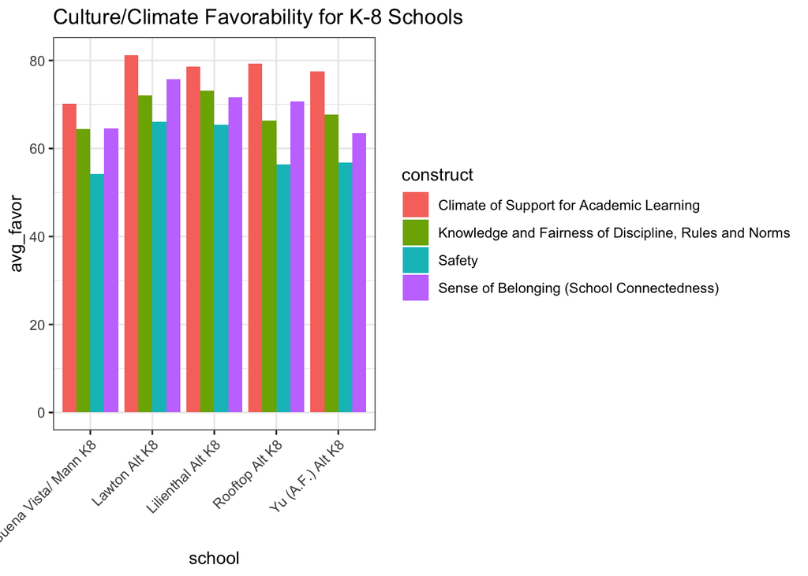

```r
ggplot(filter(surveyResponsesDF, domain == 'Culture/Climate') %>%
         group_by(school, construct) %>%
         summarise(avg_favor = mean(favorability)),
       aes(x = school, y = avg_favor, fill = construct)) +
  geom_bar(position = 'dodge', stat = 'identity') +
  labs(title = 'Culture/Climate Favorability for K-8 Schools') +
  theme_bw() +
  theme(axis.text.x = element_text(angle = 45, vjust = 1, hjust = 1))
```

Since it is difficult to get a description of what a school’s culture is like, the students’ favorability for each of the constructs gives us an idea of what their school’s culture/climate is.

```r
testScoresDF %>%
  group_by(School) %>%
  summarise(avg_ELASS = mean(ELASS),
            avg_MathSS = mean(MathSS)) %>%
  pivot_longer(cols = c('avg_ELASS', 'avg_MathSS'),
               names_to = 'measure', values_to = 'scores')
```

```
## # A tibble: 10 × 3
##    School                measure    scores
##    <chr>                 <chr>       <dbl>
##  1 Buena Vista / Mann K8 avg_ELASS   2445.
##  2 Buena Vista / Mann K8 avg_MathSS  2460.
##  3 Lawton Alt K8         avg_ELASS   2585.
##  4 Lawton Alt K8         avg_MathSS  2601.
##  5 Lilienthal Alt K8     avg_ELASS   2572.
##  6 Lilienthal Alt K8     avg_MathSS  2574.
##  7 Rooftop Alt K8        avg_ELASS   2522.
##  8 Rooftop Alt K8        avg_MathSS  2527.
##  9 Yu (A.F.) Alt K8      avg_ELASS   2581.
## 10 Yu (A.F.) Alt K8      avg_MathSS  2592.
```

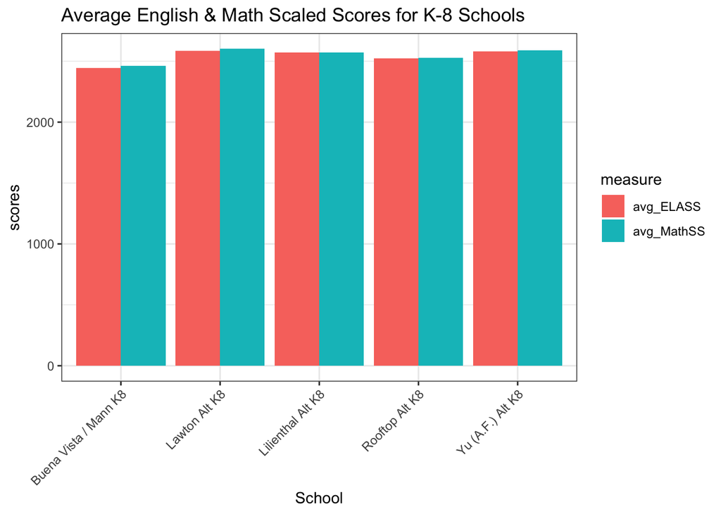

```r
ggplot(testScoresDF %>%
         group_by(School) %>%
         summarise(avg_ELASS = mean(ELASS),
                   avg_MathSS = mean(MathSS)) %>%
         pivot_longer(cols = c('avg_ELASS', 'avg_MathSS'),
                      names_to = 'measure', values_to = 'scores'),
       aes(x = School, y = scores, fill = measure)) +
  geom_bar(position = 'dodge', stat = 'identity') +
  labs(title = 'Average English & Math Scaled Scores for K-8 Schools') +
  theme_bw() +
  theme(axis.text.x = element_text(angle = 45, vjust = 1, hjust = 1))
```

It seems that the greater the overall favorability for each of the constructs that a school’s culture/climate is, the higher the average english & math scores are on the assessment.

```r
filter(surveyResponsesDF, domain == 'Culture/Climate') %>%
       group_by(school) %>%
       summarise(avg_favor = mean(favorability))
```

```
## # A tibble: 5 × 2
##   school               avg_favor
##   <chr>                    <dbl>
## 1 Buena Vista/ Mann K8      63.3
## 2 Lawton Alt K8             73.8
## 3 Lilienthal Alt K8         72.2
## 4 Rooftop Alt K8            68.2
## 5 Yu (A.F.) Alt K8          66.4
```

```r
x <- filter(surveyResponsesDF, domain == 'Culture/Climate') %>%
       group_by(school) %>%
       summarise(avg_favor = mean(favorability))
testScoresDF %>%
  group_by(School) %>%
  summarise(avg_ELASS = mean(ELASS),
            avg_MathSS = mean(MathSS),
            avg_Math_ELA = (avg_ELASS + avg_MathSS)/2)
```

```
## # A tibble: 5 × 4
##   School                avg_ELASS avg_MathSS avg_Math_ELA
##   <chr>                     <dbl>      <dbl>        <dbl>
## 1 Buena Vista / Mann K8     2445.      2460.        2453.
## 2 Lawton Alt K8             2585.      2601.        2593.
## 3 Lilienthal Alt K8         2572.      2574.        2573.
## 4 Rooftop Alt K8            2522.      2527.        2525.
## 5 Yu (A.F.) Alt K8          2581.      2592.        2586.
```

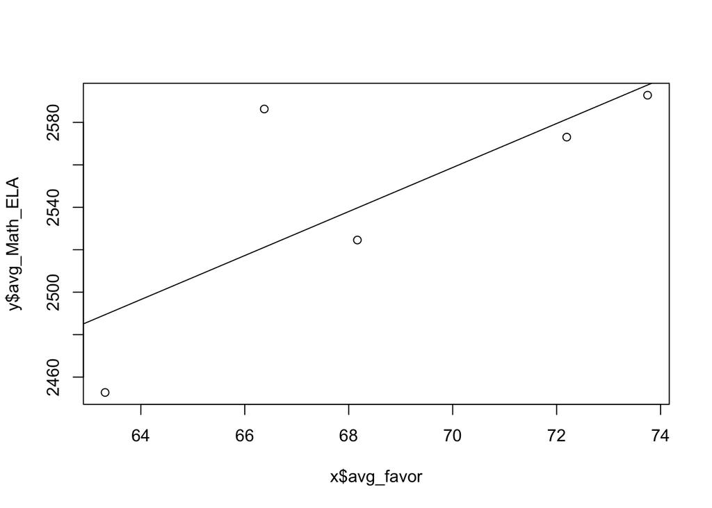

```r
y <- testScoresDF %>%
  group_by(School) %>%
  summarise(avg_ELASS = mean(ELASS),
            avg_MathSS = mean(MathSS),
            avg_Math_ELA = (avg_ELASS + avg_MathSS)/2)
plot(x$avg_favor, y$avg_Math_ELA)
abline(lm(y$avg_Math_ELA ~ x$avg_favor))
```

```r
summary(lm(y$avg_Math_ELA ~ x$avg_favor))
```

```
##
## Call:
## lm(formula = y$avg_Math_ELA ~ x$avg_favor)
##
## Residuals:
##       1       2       3       4       5
## -36.657  -4.853  -8.470 -15.171  65.150
##
## Coefficients:
##             Estimate Std. Error t value Pr(>|t|)
## (Intercept) 1832.669    359.307   5.101   0.0146 *
## x$avg_favor   10.373      5.218   1.988   0.1409
## ---
## Signif. codes:  0 '***' 0.001 '**' 0.01 '*' 0.05 '.' 0.1 ' ' 1
##
## Residual standard error: 44.4 on 3 degrees of freedom
## Multiple R-squared:  0.5685, Adjusted R-squared:  0.4247
## F-statistic: 3.952 on 1 and 3 DF,  p-value: 0.1409
```

Upon looking at the model, there doesn’t seem to be a relationship. The difference in average english & math scores on the assessment per the difference in favorability of the constructs of each school’s culture/climate is not significant enough that we can rule out that there isn’t a relationship.